# CSCI E-63C: Week 7 – Midterm Exam

Erik Lee

# Introduction

The goal of the midterm exam is to apply some of the methods for supervised and unsupervised analysis to a new dataset. We will work with data characterizing the relationship between wine quality and its analytical characteristics [available at UCI ML repository](https://archive.ics.uci.edu/ml/datasets/Wine+Quality) as well as in this course website on canvas. The overall goal will be to use data modeling approaches to understand which wine properties influence the most wine quality as determined by expert evaluation. The output variable in this case assigns wine to discrete categories between 0 (the worst) and 10 (the best), so that this problem can be formulated as classification or regression – here we will stick to the latter and treat/model outcome as a **continuous** variable (in the past there was always some discussion on piazza about it – once again, please treat it as *continuous* for the purposes of what is to be done here). For more details please see [dataset description available at UCI ML](https://archive.ics.uci.edu/ml/machine-learning-databases/wine-quality/winequality.names) or corresponding file in this course website on canvas. Please note that there is another, much smaller, dataset on UCI ML also characterizing wine in terms of its analytical properties – make sure to use correct URL as shown above, or, to eliminate possibility for ambiguity, the data available on the course website in canvas – the correct dataset contains several thousand observations. For simplicity, clarity and to decrease your dependency on the network reliability and UCI ML or canvas availability you are advised to download data made available in this course website to your local folder and work with this local copy.

There are two compilations of data available under the URL shown above as well as in the course website in canvas – separate for red and for white wine – please develop models of wine quality for each of them, investigate attributes deemed important for wine quality in both and determine whether quality of red and white wine is influenced predominantly by the same or different analytical properties (i.e. predictors in these datasets). Lastly, as an exercise in unsupervised learning you will be asked to combine analytical data for red and white wine and describe the structure of the resulting data – whether there are any well defined clusters, what subsets of observations they appear to represent, which attributes seem to affect the most this structure in the data, etc.

Finally, as you will notice, the instructions here are terser than in the previous weekly problem sets. We expect that you use what you’ve learned in the class to complete the analysis and draw appropriate conclusions based on the data. All approaches that you are expected to apply here have been exercised in the preceeding weeks – please feel free to consult your submissions and/or official solutions as to how they have applied to different datasets. As always, if something appears to be unclear, please ask questions – we may change to private mode those that in our opinion reveal too many details as we see fit.

# Sub-problem 1: load and summarize the data (20 points)

Download and read in the data, produce numerical and graphical summaries of the dataset attributes, decide whether they can be used for modeling in untransformed form or any transformations are justified, comment on correlation structure and whether some of the predictors suggest relationship with the outcome.

```r
# read red and white wine files
white_wine_data = read.table("winequality-white.csv", sep=";", header=TRUE)
red_wine_data = read.table("winequality-red.csv", sep=";", header=TRUE)

# put the outcome quality in column 1 for convenience
white_wine_data = white_wine_data[, c(12,1,2,3,4,5,6,7,8,9,10,11)]
red_wine_data = red_wine_data[, c(12,1,2,3,4,5,6,7,8,9,10,11)]

# summaries for data
summary(white_wine_data)
```

```
##     quality      fixed.acidity    volatile.acidity  citric.acid
##  Min.   :3.000   Min.   : 3.800   Min.   :0.0800   Min.   :0.0000
##  1st Qu.:5.000   1st Qu.: 6.300   1st Qu.:0.2100   1st Qu.:0.2700
##  Median :6.000   Median : 6.800   Median :0.2600   Median :0.3200
##  Mean   :5.878   Mean   : 6.855   Mean   :0.2782   Mean   :0.3342
##  3rd Qu.:6.000   3rd Qu.: 7.300   3rd Qu.:0.3200   3rd Qu.:0.3900
##  Max.   :9.000   Max.   :14.200   Max.   :1.1000   Max.   :1.6600
##  residual.sugar     chlorides       free.sulfur.dioxide
##  Min.   : 0.600   Min.   :0.00900   Min.   :  2.00
##  1st Qu.: 1.700   1st Qu.:0.03600   1st Qu.: 23.00
##  Median : 5.200   Median :0.04300   Median : 34.00
##  Mean   : 6.391   Mean   :0.04577   Mean   : 35.31
##  3rd Qu.: 9.900   3rd Qu.:0.05000   3rd Qu.: 46.00
##  Max.   :65.800   Max.   :0.34600   Max.   :289.00
##  total.sulfur.dioxide    density             pH          sulphates
##  Min.   :  9.0        Min.   :0.9871   Min.   :2.720   Min.   :0.2200
##  1st Qu.:108.0        1st Qu.:0.9917   1st Qu.:3.090   1st Qu.:0.4100
##  Median :134.0        Median :0.9937   Median :3.180   Median :0.4700
##  Mean   :138.4        Mean   :0.9940   Mean   :3.188   Mean   :0.4898
##  3rd Qu.:167.0        3rd Qu.:0.9961   3rd Qu.:3.280   3rd Qu.:0.5500
##  Max.   :440.0        Max.   :1.0390   Max.   :3.820   Max.   :1.0800
##     alcohol
##  Min.   : 8.00
##  1st Qu.: 9.50
##  Median :10.40
##  Mean   :10.51
##  3rd Qu.:11.40
##  Max.   :14.20
```

```r
summary(red_wine_data)
```

```
##     quality      fixed.acidity   volatile.acidity  citric.acid
##  Min.   :3.000   Min.   : 4.60   Min.   :0.1200   Min.   :0.000
##  1st Qu.:5.000   1st Qu.: 7.10   1st Qu.:0.3900   1st Qu.:0.090
##  Median :6.000   Median : 7.90   Median :0.5200   Median :0.260
##  Mean   :5.636   Mean   : 8.32   Mean   :0.5278   Mean   :0.271
##  3rd Qu.:6.000   3rd Qu.: 9.20   3rd Qu.:0.6400   3rd Qu.:0.420
##  Max.   :8.000   Max.   :15.90   Max.   :1.5800   Max.   :1.000
##  residual.sugar     chlorides       free.sulfur.dioxide
##  Min.   : 0.900   Min.   :0.01200   Min.   : 1.00
##  1st Qu.: 1.900   1st Qu.:0.07000   1st Qu.: 7.00
##  Median : 2.200   Median :0.07900   Median :14.00
##  Mean   : 2.539   Mean   :0.08747   Mean   :15.87
##  3rd Qu.: 2.600   3rd Qu.:0.09000   3rd Qu.:21.00
##  Max.   :15.500   Max.   :0.61100   Max.   :72.00
##  total.sulfur.dioxide    density             pH          sulphates
##  Min.   :  6.00       Min.   :0.9901   Min.   :2.740   Min.   :0.3300
##  1st Qu.: 22.00       1st Qu.:0.9956   1st Qu.:3.210   1st Qu.:0.5500
##  Median : 38.00       Median :0.9968   Median :3.310   Median :0.6200
##  Mean   : 46.47       Mean   :0.9967   Mean   :3.311   Mean   :0.6581
##  3rd Qu.: 62.00       3rd Qu.:0.9978   3rd Qu.:3.400   3rd Qu.:0.7300
##  Max.   :289.00       Max.   :1.0037   Max.   :4.010   Max.   :2.0000
##     alcohol
##  Min.   : 8.40
##  1st Qu.: 9.50
##  Median :10.20
##  Mean   :10.42
##  3rd Qu.:11.10
##  Max.   :14.90
```

```r
# correlation matricies for each dataset
cor(white_wine_data)
```

```
##                           quality fixed.acidity volatile.acidity
## quality               1.000000000   -0.11366283      -0.19472297
## fixed.acidity        -0.113662831    1.00000000      -0.02269729
## volatile.acidity     -0.194722969   -0.02269729       1.00000000
## citric.acid          -0.009209091    0.28918070      -0.14947181
## residual.sugar       -0.097576829    0.08902070       0.06428606
## chlorides            -0.209934411    0.02308564       0.07051157
## free.sulfur.dioxide   0.008158067   -0.04939586      -0.09701194
## total.sulfur.dioxide -0.174737218    0.09106976       0.08926050
## density              -0.307123313    0.26533101       0.02711385
## pH                    0.099427246   -0.42585829      -0.03191537
## sulphates             0.053677877   -0.01714299      -0.03572815
## alcohol               0.435574715   -0.12088112       0.06771794
##                       citric.acid residual.sugar   chlorides
## quality              -0.009209091    -0.09757683 -0.20993441
## fixed.acidity         0.289180698     0.08902070  0.02308564
## volatile.acidity     -0.149471811     0.06428606  0.07051157
## citric.acid           1.000000000     0.09421162  0.11436445
## residual.sugar        0.094211624     1.00000000  0.08868454
## chlorides             0.114364448     0.08868454  1.00000000
## free.sulfur.dioxide   0.094077221     0.29909835  0.10139235
## total.sulfur.dioxide  0.121130798     0.40143931  0.19891030
## density               0.149502571     0.83896645  0.25721132
## pH                   -0.163748211    -0.19413345 -0.09043946
## sulphates             0.062330940    -0.02666437  0.01676288
## alcohol              -0.075728730    -0.45063122 -0.36018871
##                      free.sulfur.dioxide total.sulfur.dioxide     density
## quality                     0.0081580671         -0.174737218 -0.30712331
## fixed.acidity              -0.0493958591          0.091069756  0.26533101
## volatile.acidity           -0.0970119393          0.089260504  0.02711385
## citric.acid                 0.0940772210          0.121130798  0.14950257
## residual.sugar              0.2990983537          0.401439311  0.83896645
## chlorides                   0.1013923521          0.198910300  0.25721132
## free.sulfur.dioxide         1.0000000000          0.615500965  0.29421041
## total.sulfur.dioxide        0.6155009650          1.000000000  0.52988132
## density                     0.2942104109          0.529881324  1.00000000
## pH                         -0.0006177961          0.002320972 -0.09359149
## sulphates                   0.0592172458          0.134562367  0.07449315
## alcohol                    -0.2501039415         -0.448892102 -0.78013762
##                                 pH   sulphates     alcohol
## quality               0.0994272457  0.05367788  0.43557472
## fixed.acidity        -0.4258582910 -0.01714299 -0.12088112
## volatile.acidity     -0.0319153683 -0.03572815  0.06771794
## citric.acid          -0.1637482114  0.06233094 -0.07572873
## residual.sugar       -0.1941334540 -0.02666437 -0.45063122
## chlorides            -0.0904394560  0.01676288 -0.36018871
## free.sulfur.dioxide  -0.0006177961  0.05921725 -0.25010394
## total.sulfur.dioxide  0.0023209718  0.13456237 -0.44889210
## density              -0.0935914935  0.07449315 -0.78013762
## pH                    1.0000000000  0.15595150  0.12143210
## sulphates             0.1559514973  1.00000000 -0.01743277
## alcohol               0.1214320987 -0.01743277  1.00000000
```

```r
cor(red_wine_data)
```

```
##                          quality fixed.acidity volatile.acidity
## quality               1.00000000    0.12405165     -0.390557780
## fixed.acidity         0.12405165    1.00000000     -0.256130895
## volatile.acidity     -0.39055778   -0.25613089      1.000000000
## citric.acid           0.22637251    0.67170343     -0.552495685
## residual.sugar        0.01373164    0.11477672      0.001917882
## chlorides            -0.12890656    0.09370519      0.061297772
## free.sulfur.dioxide  -0.05065606   -0.15379419     -0.010503827
## total.sulfur.dioxide -0.18510029   -0.11318144      0.076470005
## density              -0.17491923    0.66804729      0.022026232
## pH                   -0.05773139   -0.68297819      0.234937294
## sulphates             0.25139708    0.18300566     -0.260986685
## alcohol               0.47616632   -0.06166827     -0.202288027
##                      citric.acid residual.sugar    chlorides
## quality               0.22637251    0.013731637 -0.128906560
## fixed.acidity         0.67170343    0.114776724  0.093705186
## volatile.acidity     -0.55249568    0.001917882  0.061297772
## citric.acid           1.00000000    0.143577162  0.203822914
## residual.sugar        0.14357716    1.000000000  0.055609535
## chlorides             0.20382291    0.055609535  1.000000000
## free.sulfur.dioxide  -0.06097813    0.187048995  0.005562147
## total.sulfur.dioxide  0.03553302    0.203027882  0.047400468
## density               0.36494718    0.355283371  0.200632327
## pH                   -0.54190414   -0.085652422 -0.265026131
## sulphates             0.31277004    0.005527121  0.371260481
## alcohol               0.10990325    0.042075437 -0.221140545
##                      free.sulfur.dioxide total.sulfur.dioxide     density
## quality                     -0.050656057          -0.18510029 -0.17491923
## fixed.acidity               -0.153794193          -0.11318144  0.66804729
## volatile.acidity            -0.010503827           0.07647000  0.02202623
## citric.acid                 -0.060978129           0.03553302  0.36494718
## residual.sugar               0.187048995           0.20302788  0.35528337
## chlorides                    0.005562147           0.04740047  0.20063233
## free.sulfur.dioxide          1.000000000           0.66766645 -0.02194583
## total.sulfur.dioxide         0.667666450           1.00000000  0.07126948
## density                     -0.021945831           0.07126948  1.00000000
## pH                           0.070377499          -0.06649456 -0.34169933
## sulphates                    0.051657572           0.04294684  0.14850641
## alcohol                     -0.069408354          -0.20565394 -0.49617977
##                               pH    sulphates     alcohol
## quality              -0.05773139  0.251397079  0.47616632
## fixed.acidity        -0.68297819  0.183005664 -0.06166827
## volatile.acidity      0.23493729 -0.260986685 -0.20228803
## citric.acid          -0.54190414  0.312770044  0.10990325
## residual.sugar       -0.08565242  0.005527121  0.04207544
## chlorides            -0.26502613  0.371260481 -0.22114054
## free.sulfur.dioxide   0.07037750  0.051657572 -0.06940835
## total.sulfur.dioxide -0.06649456  0.042946836 -0.20565394
## density              -0.34169933  0.148506412 -0.49617977
## pH                    1.00000000 -0.196647602  0.20563251
## sulphates            -0.19664760  1.000000000  0.09359475
## alcohol               0.20563251  0.093594750  1.00000000
```

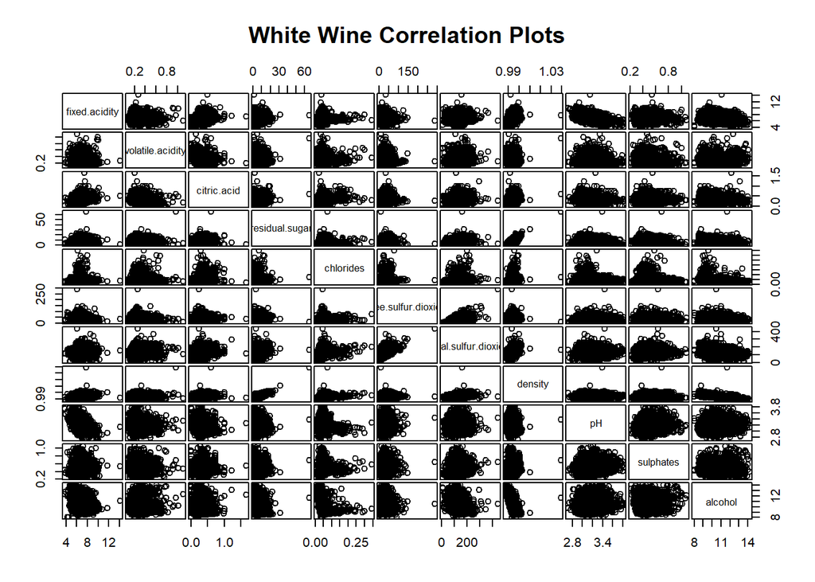

```r
# plotting correlation of all continous variables (all attributes and outcome are continous in this case)
pairs(white_wine_data[,2:ncol(white_wine_data)], gap=0.2, main="White Wine Correlation Plots")
```

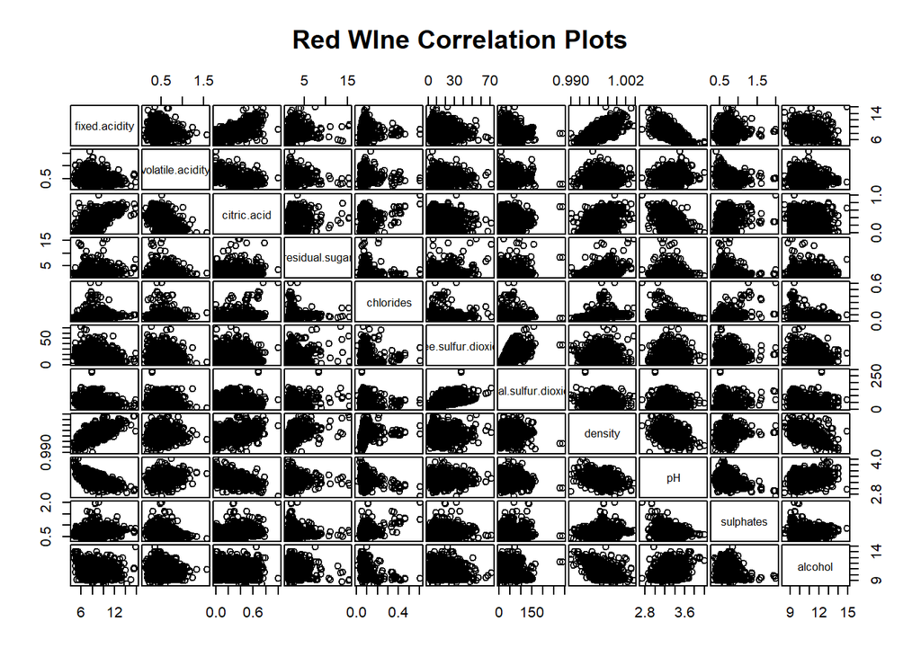

```r
pairs(red_wine_data[,2:ncol(red_wine_data)], gap=0.2, main="Red WIne Correlation Plots")
```

Based on the information from the correlation matrix and paired XY-scatterplots of the red wine and white wine data sets, there are no strong relations between the attributes and the outcome, quality. This makes sense because Quality, the outcome, is not continuous, even though in the context of these prbolems we consider it so. If we look at the data summary and data tables, Quality is rated from 0 to 10 and assumes integer values. If we plotted that against any of the attributes, we’d see columns corresponding to each rating level, and it would be hard to determine a clear linear relationship from the two. Thus it is important to look at the correlations of each attribute and outcome relative to each other to see which attributes are closer in correlation to the outocme.

The strongest correlation with quality is with alcohol at 0.43 and 0.47 for white and red wine, respectively. The next highest correlation in the white wine dataset is between quality and density at -0.30 For red wine, that is between quality and volatile acidity at -0.39.

Aside from those, overall the correlations between quality and the attributs is low. For the White Wine data, the next few correlations with the Quality are Clorides (-0.20), Volatile Acidity (-0.19), Total Sulfur Dioxides (-0.18), and Fixed Acidity (-0.11). We also see low correlation with Quality from pH (0.09), Residual Sugar (-0.09), Sulphates (0.05), Citric ACid (-0.009), and Free Sulfur Dioxides (0.008). These may be interesting attributes to remove when deciding important variables for the model.

Red Wine show different correlations with Quality from Sulphats (0.25), Citric Acid (0.22), Total Sulfur Dioxide (-0.18), Density (-0.17), Chlorides (-0.12), and Fixed Acidity (0.12). The low correlations with Quality are from pH (-0.05), Free Sulfur Dioxides, and Residual Sugar (0.02). These will also be interesting removals for variable selection.

The pair plots and correlation matricies show interesting information about the relations among the attributes. We can see some collinearity, in the white wine dataset, among attributes such as Density and Residual Sugar (0.83), Density and Alcohol (-0.78), and Free Sulfur Dioxide and Total Sulfur Dioxide (0.61). For the red wine dataset, we see possible collinearity from Fixed Acidity with pH (-0.68), Density (0.66), and Citric Acid (0.67). Let us see if Fixed Acidity can be included in the model as standin for any of these three attributes, or vice versa. Additionally, there is correlation between Free and Total Sulfur Dioxide (0.66). Again, we want to see if these collinearities can help in selection for the White Wine and Red Wine models.

The next best thing to do is log transform the data sets, which includes the outcome and attributes, to see if these plot shows any more infromation about linearity. From there, we can worked with transformed versions of the white wine and red wine datasets for further analysis.

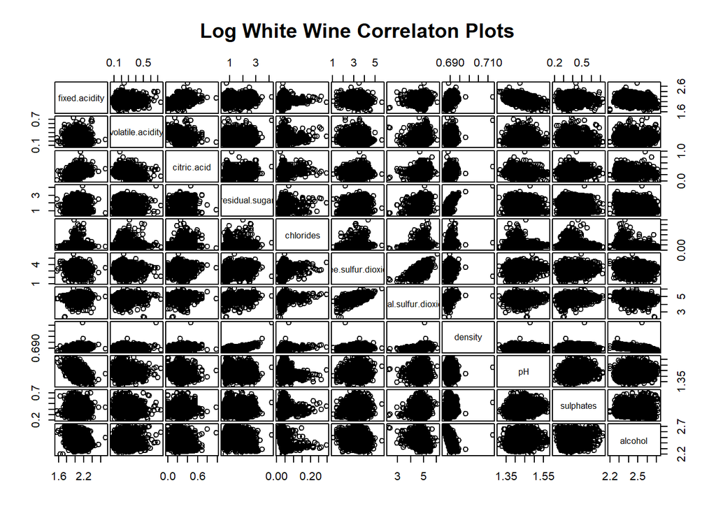

```r
# log-transformation for white wine (ww) and red wine (rw)
ww_logdata = log(white_wine_data+1)
rw_logdata = log(red_wine_data+1)

# pair plots
pairs(ww_logdata[,2:ncol(ww_logdata)], gap=0.2, main="Log White Wine Correlaton Plots")
```

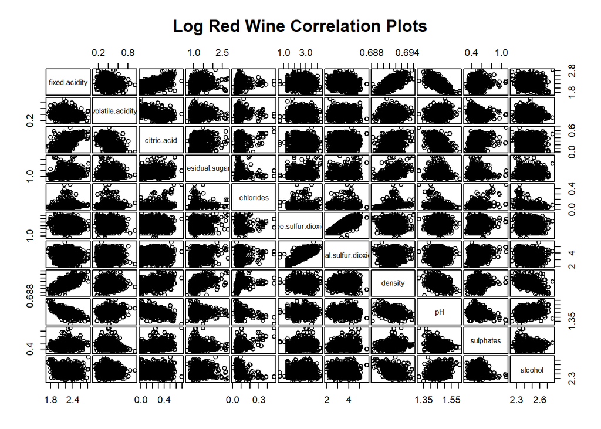

```r
pairs(rw_logdata[,2:ncol(rw_logdata)], gap=0.2, main="Log Red Wine Correlation Plots")
```

After log transforming both datasets and plotting the pair plots, we see some new information from the pairs plot regarding linearlity among the variables. We see a postive linear pattern for the plot of Free Sulfur Dioxide and Total Sulfur Dioxide. Ther is also a positive linear pattern for the plot of Fixed Acidity and Density. And we see a negative linear pattern for the plot of Fixed Acidity and pH. Since we can more easily discern linear patterns among the XY-scatterplots of the attributes, we are going to continue the our data analysis with log-transformed White Wine and Red Wine datasets.

```r
# continue with the log-transformed White Wine and Red Wine datasets
white_wine_data = ww_logdata
red_wine_data = rw_logdata
```

# Sub-problem 2: choose optimal models by exhaustive, forward and backward selection (20 points)

Use `regsubsets` from library `leaps` to choose optimal set of variables for modeling wine quality for red and white wine (separately), describe differences and similarities between attributes deemed important in each case.

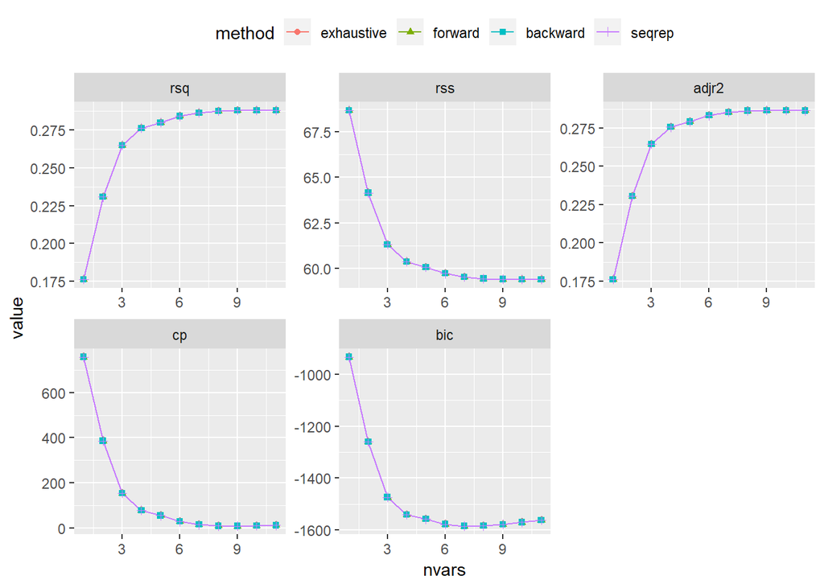

```r
# White Wine Dataset

meths = c("exhaustive", "forward", "backward", "seqrep")
metrics = c("rsq", "rss", "adjr2", "cp", "bic")
wchAll = list()
sumMet = NULL

for(method in meths){
  rgSub = regsubsets(white_wine_data$quality~., white_wine_data, method=method, nvmax=11)
  summ = summary(rgSub)
  wchAll[[method]] = summ$which
  for(metric in metrics){
    sumMet = rbind(sumMet, data.frame(method=method, metric=metric, nvars=1:length(summ[[metric]]), value=summ[[metric]]))
  }
}

ggplot(sumMet, aes(x=nvars, y=value, shape=method, colour=method)) + geom_path() + geom_point() +
  facet_wrap(~metric, scales="free") + theme(legend.position="top")
```

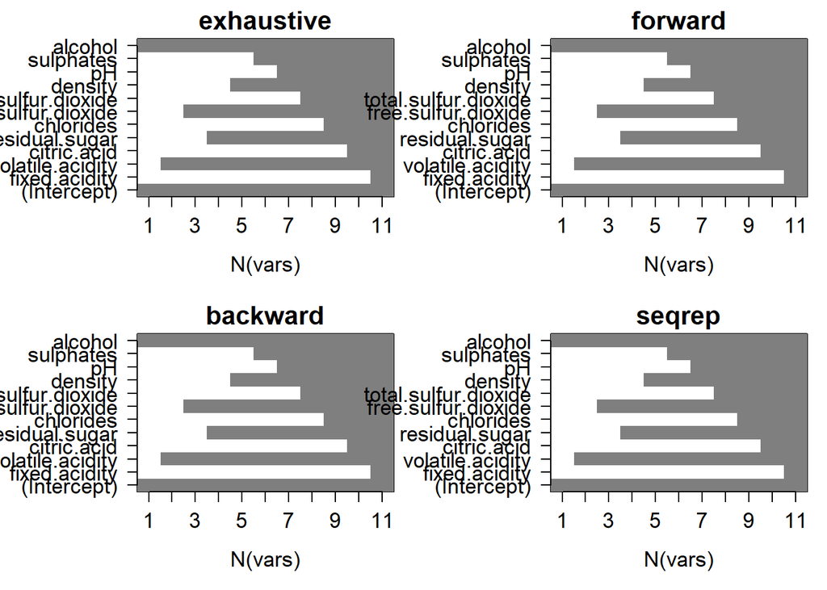

```r
# matrix of selected variables White Wine
old.par = par(mfrow=c(2,2), ps=16, mar=c(5,7,2,1))
for(method in names(wchAll)){
  image(1:nrow(wchAll[[method]]), 1:ncol(wchAll[[method]]), wchAll[[method]], xlab="N(vars)", ylab="",
        xaxt="n", yaxt="n", breaks=c(-0.5,0.5,1.5), col=c("white", "gray50"), main=method)
  axis(1, 1:nrow(wchAll[[method]]), rownames(wchAll[[method]]))
  axis(2, 1:ncol(wchAll[[method]]), colnames(wchAll[[method]]), las=2)
}
```

```r
par(old.par)
```

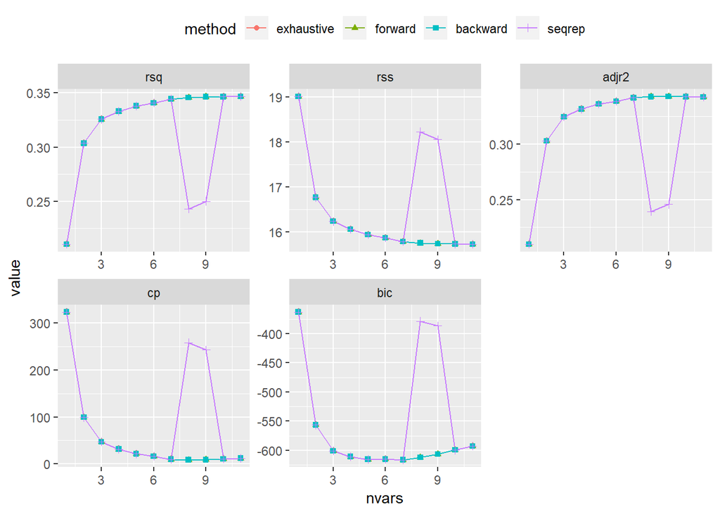

```r
# Red Wine dataset

metricSummary = NULL
whichAll = list()
for(method in meths){
  rgSub = regsubsets(red_wine_data$quality~., red_wine_data, method=method, nvmax=11)
  summ = summary(rgSub)
  whichAll[[method]] = summ$which
  for(metric in metrics){
    metricSummary = rbind(metricSummary, data.frame(method=method, metric=metric, nvars=1:length(summ[[metric]]), value=summ[[metric]]))
  }
}

ggplot(metricSummary, aes(x=nvars, y=value, shape=method, colour=method)) + geom_path() + geom_point() + facet_wrap(~metric, scales="free") + theme(legend.position="top")
```

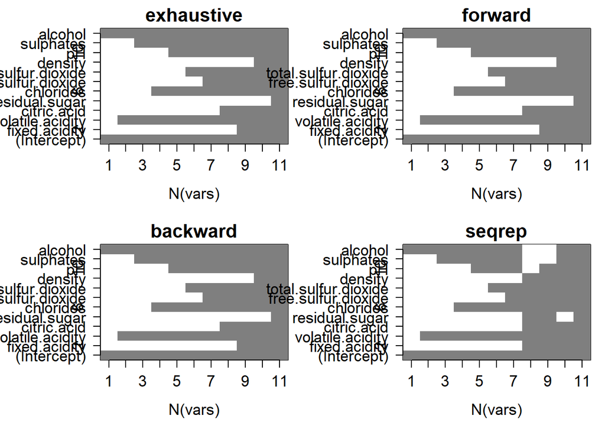

```r
# matrix of selected variables Red Wine
old.par = par(mfrow=c(2,2), ps=16, mar=c(5,7,2,1))
for(method in names(whichAll)){
  image(1:nrow(whichAll[[method]]), 1:ncol(whichAll[[method]]), whichAll[[method]], xlab="N(vars)", ylab="", xaxt="n", breaks=c(-0.5, 0.5, 1.5), col=c("white", "gray50"), main=method)
  axis(1, 1:nrow(whichAll[[method]]), rownames(whichAll[[method]]))
  axis(2, 1:ncol(whichAll[[method]]), colnames(whichAll[[method]]), las=2)
}
```

# Sub-problem 3: optimal model by cross-validation (25 points)

Use cross-validation (or any other resampling strategy of your choice) to estimate test error for models with different numbers of variables. Compare and comment on the number of variables deemed optimal by resampling versus those selected by `regsubsets` in the previous task. Compare resulting models built separately for red and white wine data.

```r
# method for predict regsubsets
predict.regsubsets <- function (object, newdata, id, ...){
  form=as.formula(object$call [[2]])
  mat=model.matrix(form,newdata)
  coefi=coef(object,id=id)
  xvars=names (coefi)
  mat[,xvars] %*% coefi
}
```

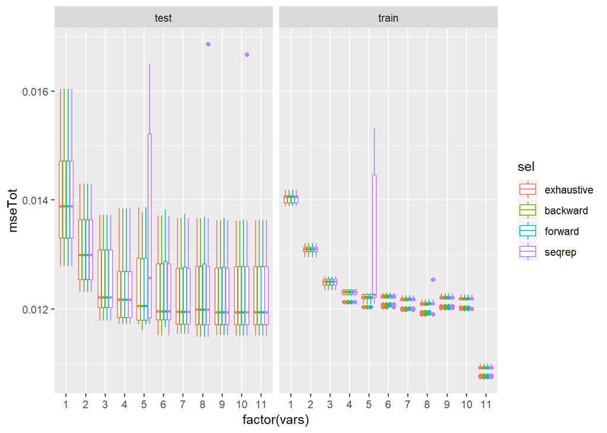

```r
# cross validation with White Wine Data

# set seed for consistent results
set.seed(2)

tempDF = NULL
kFolds = 10
folds = sample(1:kFolds, nrow(white_wine_data), replace=TRUE)
cv.errors = matrix(NA, kFolds, 11, dimnames=list(NULL, paste(1:11)))
for(k in 1:kFolds){
  for(j in c("exhaustive", "backward", "forward", "seqrep")){
    regSub = regsubsets(quality~., white_wine_data[folds!=k,], nvmax=11, method=j)
    for(i in 1:11){
      pred = predict(regSub, white_wine_data[folds==k, ], id=i)
      cv.errors[k,i] = mean((white_wine_data$quality[folds==k] - pred)^2)
      testMSE = mean((white_wine_data$quality[folds==k] - pred)^2)
      tempDF = rbind(tempDF, data.frame(fold=k, sel=j, vars=i, mseTot = c(testMSE, summary(regSub)$rss[i]/sum(folds!=i)), trainsTest=c("test", "train")))
    }
  }
}
ggplot(tempDF, aes(x=factor(vars), y=mseTot, colour=sel)) + geom_boxplot() + facet_wrap(~trainsTest)
```

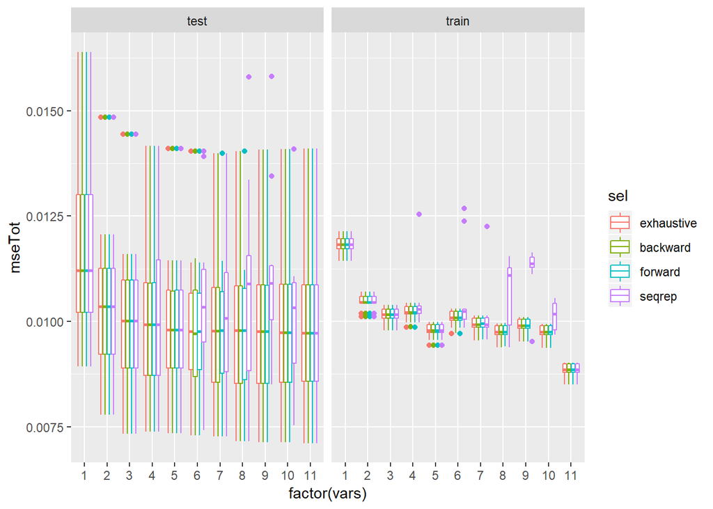

```r
# cross validation with the Red Wine dataset

# set seed for consistent results
set.seed(3)

mseVect = numeric()

tempDF2 = NULL
folds2 = sample(1:kFolds, nrow(red_wine_data), replace=TRUE)
cv.errors2 = matrix(NA, kFolds, 11, dimnames=list(NULL, paste(1:11)))
for(k in 1:kFolds){
  for(j in c("exhaustive", "backward", "forward", "seqrep")){
    regSub = regsubsets(quality~., red_wine_data[folds!=k,], nvmax=11, method=j)
    for(i in 1:11){
      pred = predict(regSub, red_wine_data[folds2==k,], id=i)
      cv.errors2[k,i] = mean((red_wine_data$quality[folds2==k] - pred)^2)
      testMSE = mean((red_wine_data$quality[folds2==k] - pred)^2)
      if(i==11){mseVect = c(mseVect, testMSE)} # save 11 variable MSE for extra credit
      tempDF2 = rbind(tempDF2, data.frame(fold=k, sel=j, vars=i, mseTot=c(testMSE, summary(regSub)$rss[i]/sum(folds2!=i)), trainsTest=c("test", "train")))
    }
  }
}
ggplot(tempDF2, aes(x=factor(vars), y=mseTot, colour=sel)) + geom_boxplot() + facet_wrap(~trainsTest)
```

# Sub-problem 4: lasso/ridge (25 points)

Use regularized approaches (i.e. lasso and ridge) to model quality of red and white wine (separately). Compare resulting models (in terms of number of variables and their effects) to those selected in the previous two tasks (by `regsubsets` and resampling), comment on differences and similarities among them.

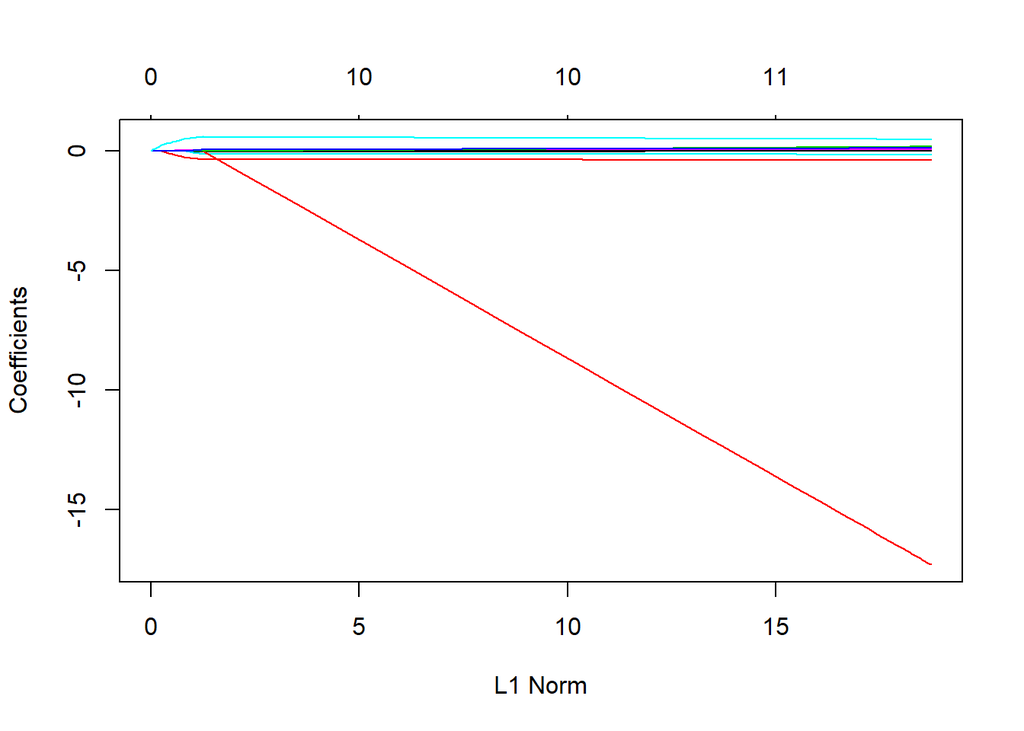

```r
# White Wine Lasso
xVals = model.matrix(quality~., white_wine_data)[, -1]
yVals = white_wine_data[, "quality"]

lasso = glmnet(xVals, yVals, alpha=1)
plot.glmnet(lasso)
```

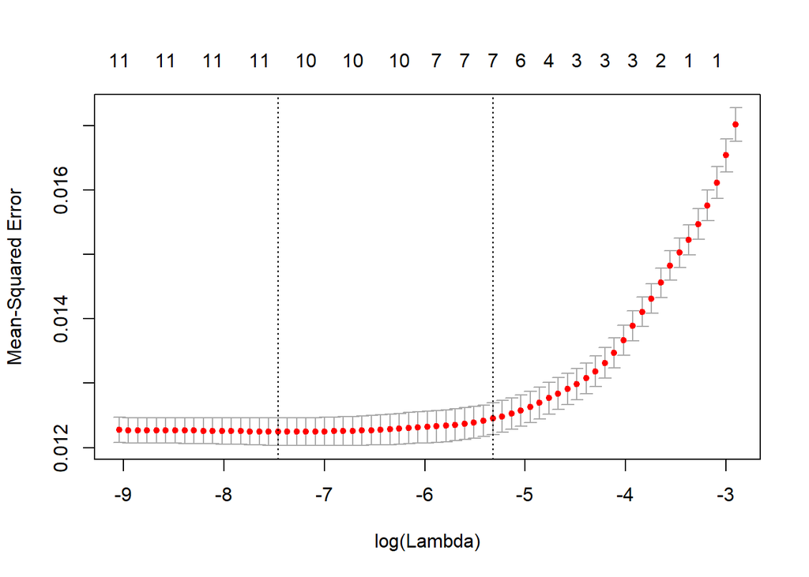

```r
# CV Lasso
cvLasso = cv.glmnet(xVals, yVals, alpha=1)
plot(cvLasso)
```

```r
cvLasso$lambda.min
```

```
## [1] 0.0005741079
```

```r
cvLasso$lambda.1se
```

```
## [1] 0.004878501
```

```r
predict(cvLasso, type="coefficients", s=cvLasso$lambda.min)
```

```
## 12 x 1 sparse Matrix of class "dgCMatrix"
##                                  1
## (Intercept)            9.922618396
## fixed.acidity         -0.014002971
## volatile.acidity      -0.377034324
## citric.acid            0.003428728
## residual.sugar         0.038700425
## chlorides             -0.149512413
## free.sulfur.dioxide    0.041302125
## total.sulfur.dioxide  -0.014590738
## density              -13.729071334
## pH                     0.136270265
## sulphates              0.099387767
## alcohol                0.502067788
```

```r
predict(cvLasso, type="coefficients", s=cvLasso$lambda.1se)
```

```
## 12 x 1 sparse Matrix of class "dgCMatrix"
##                                1
## (Intercept)           0.59143992
## fixed.acidity        -0.02994861
## volatile.acidity     -0.32534212
## citric.acid           .
## residual.sugar        0.01095060
## chlorides            -0.08720992
## free.sulfur.dioxide   0.03204527
## total.sulfur.dioxide  .
## density               .
## pH                    .
## sulphates             0.01844035
## alcohol               0.54760804
```

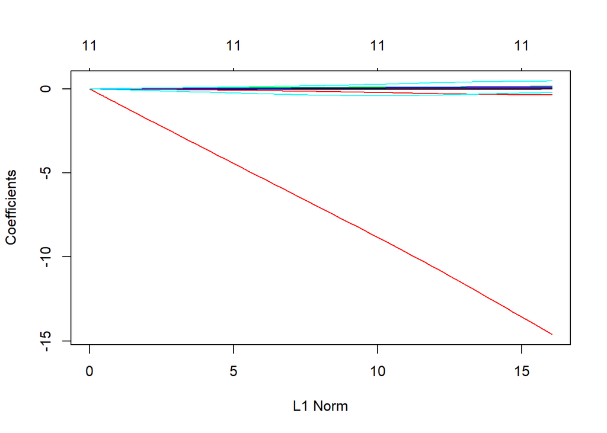

```r
# White Wine Lasso
ridge = glmnet(xVals, yVals, alpha=0)
plot.glmnet(ridge)
```

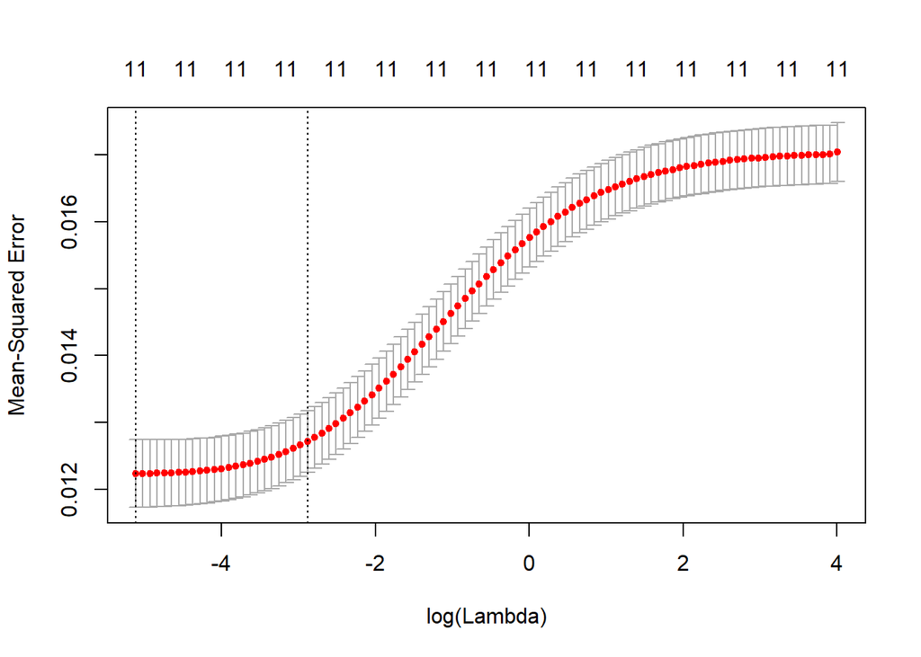

```r
# CV Lasso
cvRidge = cv.glmnet(xVals, yVals, alpha=0)
plot(cvRidge)
```

```r
cvRidge$lambda.min
```

```
## [1] 0.006014445
```

```r
cvRidge$lambda.1se
```

```
## [1] 0.05609091
```

```r
predict(cvRidge, type="coefficients", s=cvRidge$lambda.min)
```

```
## 12 x 1 sparse Matrix of class "dgCMatrix"
##                                 1
## (Intercept)           10.50875478
## fixed.acidity         -0.01968376
## volatile.acidity      -0.35790820
## citric.acid            0.01722132
## residual.sugar         0.03712071
## chlorides             -0.22484688
## free.sulfur.dioxide    0.04152914
## total.sulfur.dioxide  -0.01777812
## density              -14.43023263
## pH                     0.14700773
## sulphates              0.10270835
## alcohol                0.46314748
```

```r
predict(cvRidge, type="coefficients", s=cvRidge$lambda.1se)
```

```
## 12 x 1 sparse Matrix of class "dgCMatrix"
##                                1
## (Intercept)           7.76629621
## fixed.acidity        -0.03828199
## volatile.acidity     -0.24850968
## citric.acid           0.02526338
## residual.sugar        0.01595657
## chlorides            -0.40629134
## free.sulfur.dioxide   0.02966972
## total.sulfur.dioxide -0.01178878
## density              -9.72207828
## pH                    0.09934844
## sulphates             0.06789277
## alcohol               0.31614141
```

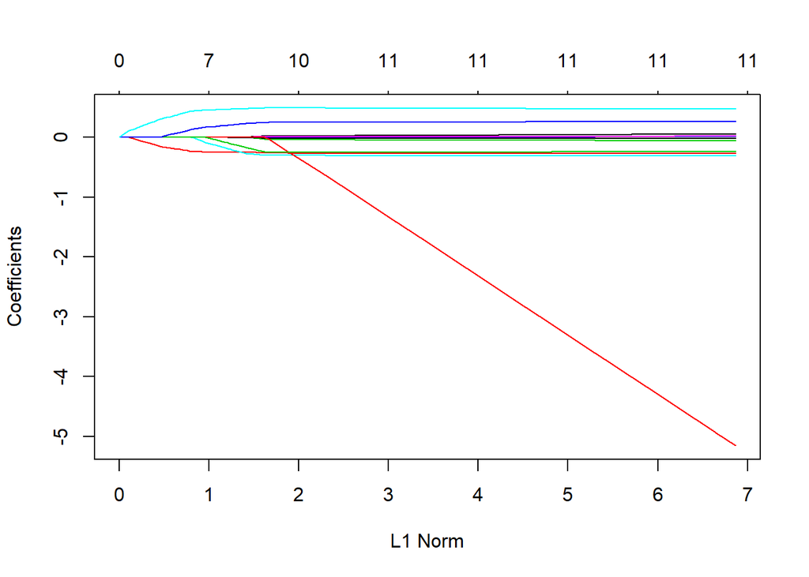

```r
x = model.matrix(quality~., red_wine_data)[,-1]
y = red_wine_data[, "quality"]

lassoRed = glmnet(x, y, alpha=1)
plot.glmnet(lassoRed)
```

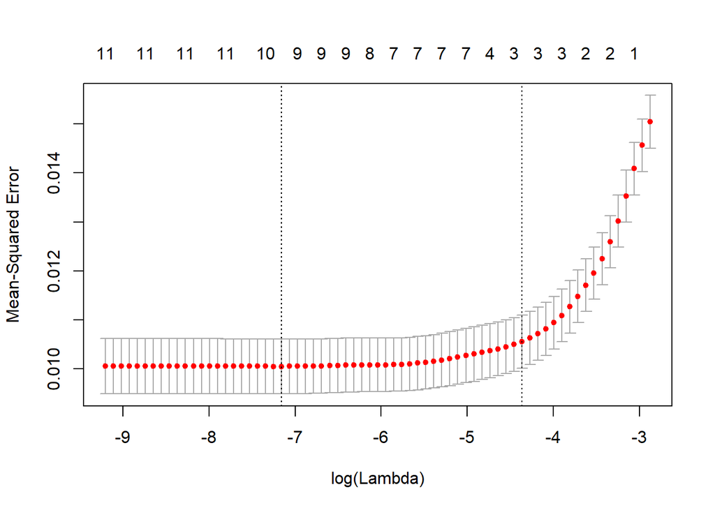

```r
# cv lasso
cvLassoRed = cv.glmnet(x, y, alpha=1)
plot(cvLassoRed)
```

```r
cvLassoRed$lambda.min
```

```
## [1] 0.0007794846
```

```r
cvLassoRed$lambda.1se
```

```
## [1] 0.01270366
```

```r
predict(cvLassoRed, type="coefficients", s=cvLassoRed$lambda.min)
```

```
## 12 x 1 sparse Matrix of class "dgCMatrix"
##                                1
## (Intercept)           1.23195506
## fixed.acidity         0.02136043
## volatile.acidity     -0.26542122
## citric.acid          -0.03854138
## residual.sugar        .
## chlorides            -0.30390238
## free.sulfur.dioxide   0.01167086
## total.sulfur.dioxide -0.01644924
## density              -0.23778429
## pH                   -0.25069088
## sulphates             0.24760731
## alcohol               0.48778256
```

```r
predict(cvLassoRed, type="coefficients", s=cvLassoRed$lambda.1se)
```

```
## 12 x 1 sparse Matrix of class "dgCMatrix"
##                               1
## (Intercept)           0.9276177
## fixed.acidity         .
## volatile.acidity     -0.2196203
## citric.acid           .
## residual.sugar        .
## chlorides             .
## free.sulfur.dioxide   .
## total.sulfur.dioxide  .
## density               .
## pH                    .
## sulphates             0.1042752
## alcohol               0.4099623
```

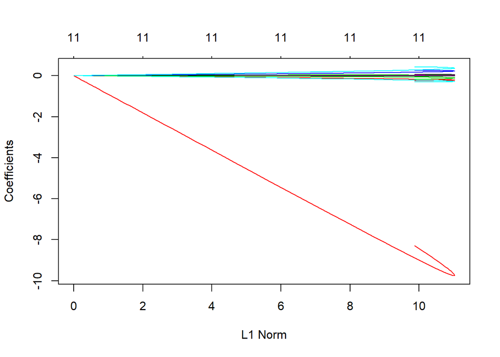

```r
ridgeRed = glmnet(x, y, alpha=0)
plot.glmnet(ridgeRed)
```

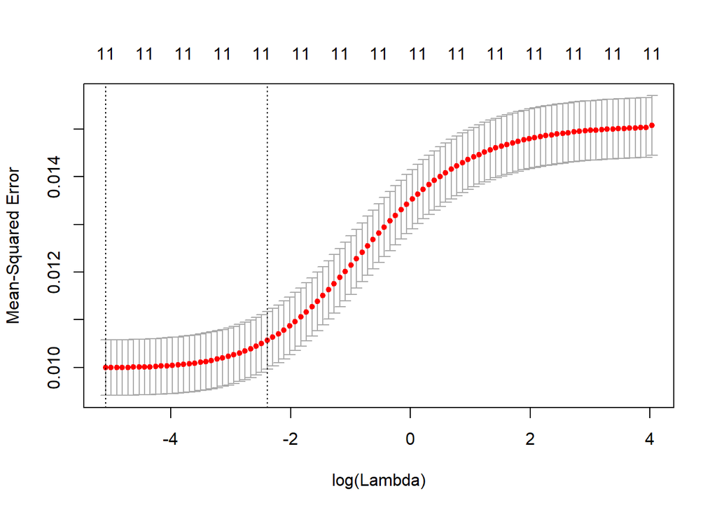

```r
# cv ridge
cvRidgeRed = cv.glmnet(x, y , alpha=0)
plot(cvRidgeRed)
```

```r
cvRidgeRed$lambda.min
```

```
## [1] 0.006177282
```

```r
cvRidgeRed$lambda.1se
```

```
## [1] 0.09173068
```

```r
predict(cvRidgeRed, type="coefficients", s=cvLassoRed$lambda.min)
```

```
## 12 x 1 sparse Matrix of class "dgCMatrix"
##                                1
## (Intercept)           6.72893105
## fixed.acidity         0.05847001
## volatile.acidity     -0.25652741
## citric.acid          -0.04122899
## residual.sugar        0.01151865
## chlorides            -0.31257785
## free.sulfur.dioxide   0.01380927
## total.sulfur.dioxide -0.01859109
## density              -8.27986704
## pH                   -0.18370700
## sulphates             0.25953310
## alcohol               0.43183690
```

```r
predict(cvRidgeRed, type="coefficients", s=cvLassoRed$lambda.1se)
```

```
## 12 x 1 sparse Matrix of class "dgCMatrix"
##                                1
## (Intercept)           7.38185906
## fixed.acidity         0.05382867
## volatile.acidity     -0.23990834
## citric.acid          -0.02173970
## residual.sugar        0.01158386
## chlorides            -0.30524128
## free.sulfur.dioxide   0.01161867
## total.sulfur.dioxide -0.01711507
## density              -9.19173443
## pH                   -0.15372959
## sulphates             0.24854111
## alcohol               0.40633859
```

Starting with White Wine, the Lasso regression selects all 11 variables for the lowest MSE and 7 variable model for 1se (1 standard error from lowest MSE). The 7 variable model selects against Citric Acid, Total Sulfur Dioxide, Density, and pH. We have a similar amount of variables as the cross-validation for White Wine above, which has a median test MSE that levels out at the 6 variable model. We also see in the four methods of regsubsets (exhaustive, forward, backward, seqrep) that the last variables to be included are Total Sulfur Dioxide (at 8 variables), Chlorides (at 9 variables), Citric Acid (at 10 variables), and Fixed Acidity (11 variables). We see an agreement between Lasso and regsubsets that Total Sulfur Dioxide and Citric Acid can be removed in an 7 variable model.

The Ridge Regression tracking lowest MSE and 1se minimized coefficients for Total SUlfur Dioxide, Residual Sugar, Citric Acid, and Fixed Acidity. We also saw earlier in the correlation matricies of White Wine that Free and Total Sulfur Dioxide are correlated so Free Sulfur Dioxide could explain enough of Quality in place of Total. And we also saw that Residual Sugar and Density are correlated, where Density could stand in for Residual Sugar for explaining Quality.

Ridge Regression is minmizing coefficients for Fixed Acidity, Citric Acid, Residual Sugar, Free Sulfur Dioxide, and Total Sulfur Dioxide for min and 1se. From regsubsets, we see the last variables to be included are Citric Acid (at 8 variables), Fixed Acidity (at 9 variables), Density (at 10 variables), and Residual Sugar (at 11 variables) for modeling Quality. Agreement between Ridge Regression and regsubsets indicats that Residual Sugar, Fixed Acidity, and Citric Acid are attributes that can be omitted from the modeling Red Wine. It is interesting to note that although Density is one of the attributes that can be omitted in modeling, according to regsubsets, Density still maintains high coefficient values for Lasso and Ridge regression, but 1se Lasso for Red Wine does remove Density.

# Sub-problem 5: PCA (10 points)

Merge data for red and white wine (function `rbind` allows merging of two matrices/data frames with the same number of columns) and plot data projection to the first two principal components (e.g. biplot or similar plots). Does this representation suggest presence of clustering structure in the data? Does wine type (i.e. red or white) or quality appear to be associated with different regions occupied by observations in the plot? Please remember *not* to include quality attribute or wine type (red or white) indicator in your merged data, otherwise, apparent association of quality or wine type with PCA layout will be influenced by presence of those indicators in your data.

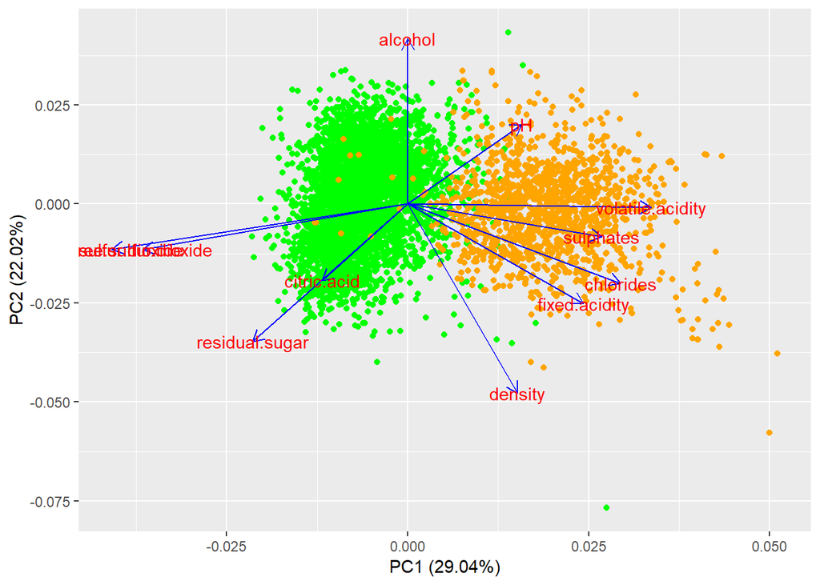

```r
# add color column for red and white wine
white_wine_data2 = white_wine_data
white_wine_data2$color = "green"

red_wine_data2 = red_wine_data
red_wine_data2$color = "orange"

# row bind of red and white wine data sets
white_and_red_data = rbind(white_wine_data2, red_wine_data2)

# load ggfortify for autoplot to be able to interpret+plot prcomp()
library(ggfortify)
# remove the quality / outcome column
white_and_red_data = white_and_red_data[, -1]

# principle component analysis on white+red wine dataset, only use columns 1-11 (variables) not 12 (color)
pr.out = prcomp(white_and_red_data[, 1:11], scale=TRUE)

# biplot of PC1 and PC2
autoplot(pr.out, data=white_and_red_data, colour=white_and_red_data$color, loadings=TRUE, loadings.colour="blue", loadings.label=TRUE)
```

There is a presence of a clustering structure in the aggregated data for White and Red wines. In its entirety, all the points cluster in a mass centered at PC1 = 0 and PC2 = 0. The White Wine points are mostly clustered to the left of PC1 = 0 (negative PC1) - a portion of the green cluster does fall in positive PC1 values - and are spread evenly above and below PC2 = 0. The Red Wine points are clustered to the right of PC1 = 0 (positive PC1) and evenly spread above and below PC2 = 0.

Based on the locations and magnitudes of the loading vectors, we see several associations with the variables and the principle components. PC1 has a negative vector for Total and Free Sulfur Dioxide and positive vector for Volatile Acidity and Sulphates. PC1 could focus on the acidity and fermentation of the White and Red wines. PC2 has a negative vector for Density and postive vector for Alcohol. PC2 could focus on the texture of the wine such as alcohol content, density, and viscosity.